CNS Drugs (2019) 33:755–770

https://doi.org/10.1007/s40263-019-00650-2

**SYSTEMATIC REVIEW**

**Branched‑Chain Amino Acids and Seizures: A Systematic Review**

**of the Literature**

**Shaun E. Gruenbaum**<sup>**1**</sup> **· Eric C. Chen**<sup>**2**</sup> **· Mani Ratnesh Singh Sandhu**<sup>**2**</sup> **· Ketaki Deshpande**<sup>**2**</sup> **· Roni Dhaher**<sup>**2**</sup> **·**

**Denise Hersey**<sup>**3**</sup> **· Tore Eid**<sup>**2**</sup>

Published online: 16 July 2019

© Springer Nature Switzerland AG 2019

**Abstract**

**Background** Up to 40% of patients with epilepsy experience seizures despite treatment with antiepileptic drugs; however,

branched-chain amino acid (BCAA) supplementation has shown promise in treating refractory epilepsy.

**Objectives** The purpose of this systematic review was to evaluate all published studies that investigated the effects of BCAAs

on seizures, emphasizing therapeutic efficacy and possible underlying mechanisms.

**Methods** On 31 January, 2017, the following databases were searched for relevant studies: MEDLINE (OvidSP), EMBASE

(OvidSP), Scopus (Elsevier), the Cochrane Library, and the unindexed material in PubMed (National Library of Medicine/

National Institutes of Health). The searches were repeated in all databases on 18 February, 2019. We only included full-length

preclinical and clinical studies that were published in the English language that examined the effects of BCAA administra-

tion on seizures.

**Results** Eleven of 2045 studies met our inclusion criteria: ten studies were conducted in animal models and one study

in human subjects. Seven seizure models were investigated: the strychnine (one study), pentylenetetrazole (two studies),

flurothyl (one study), picrotoxin (two studies), genetic absence epilepsy in rats (one study), kainic acid (two studies), and

methionine sulfoximine (one study) paradigms. Three studies investigated the effect of a BCAA mixture whereas the other

studies explored the effects of individual BCAAs on seizures. In most animal models and in humans, BCAAs had potent

anti-seizure effects. However, in the methionine sulfoximine model, long-term BCAA supplementation worsened seizure

propagation and caused neuron loss, and in the genetic absence epilepsy in rats model, BCAAs exhibited pro-seizure effects.

**Conclusions** The contradictory effects of BCAAs on seizure activity likely reflect differences in the complex mechanisms

that underlie seizure disorders. Some of these mechanisms are likely mediated by BCAA’s effects on glucose, glutamate,

glutamine, and ammonia metabolism, activation of the mechanistic target of rapamycin signaling pathway, and their effects

on aromatic amino acid transport and neurotransmitter synthesis. We propose that a better understanding of mechanisms by

which BCAAs affect seizures and neuronal viability is needed to advance the field of BCAA supplementation in epilepsy.

**Electronic supplementary material** The online version of this

article (https ://doi.org/10.1007/s4026 3-019-00650 -2) contains

supplementary material, which is available to authorized users.

*<sup>Shaun E. Gruenbaum</sup>

gruenbaum.shaun@mayo.edu

Eric C. Chen

eric.c.chen@yale.edu

Mani Ratnesh Singh Sandhu

maniratnesh.sandhu@yale.edu

Ketaki Deshpande

ketaki.deshpande@yale.edu

Roni Dhaher

roni.dhaher@yale.edu

Denise Hersey

dhersey@princeton.edu

Tore Eid

tore.eid@yale.edu

1

Department of Anesthesiology and Perioperative Medicine,

Mayo Clinic, Jacksonville, FL, USA

2

Department of Laboratory Medicine, Yale School

of Medicine, New Haven, CT, USA

3

Lewis Science Library, Princeton University, Princeton, NJ,

USA

756

S. E. Gruenbaum et al.

**Key Points**

Recent studies have shown that the branched-chain

amino acids valine, leucine, and isoleucine can modu-

late seizure activity in both human epilepsy and animal

models of epilepsy.

The majority of studies in humans and animal models of

epilepsy demonstrated potent anticonvulsant effects of

branched-chain amino acids; two animal studies however

suggested possible pro-convulsant effects.

The complex effects of branched-chain amino acids

on seizures are likely mediated by their modulation of

glucose, glutamate, glutamine, and ammonia metabo-

lism, activation of the mechanistic target of rapamycin

signaling pathway, and their effects on aromatic amino

acid transport and neurotransmitter synthesis.

**1 Introduction**

Epilepsy is a heterogeneous group of chronic neurological

disorders characterized by recurrent spontaneous seizures

[1]. Seizures are typically unpredictable and occur without

warning, and are often associated with significant morbid-

ity including memory and cognitive impairment. Epilepsy

affects approximately 1% of the population [2] and carries a

significant societal burden, with annual costs in the USA as

high as US$20 billion [3]. Current epileptic therapies fail to

control seizures in up to 40% of patients; therefore, there is a

great need for the discovery of new methods to treat seizures

[4, 5]. In most cases, the cause of epilepsy is unknown, and

the pathophysiology of how epilepsy develops after a brain

insult (i.e., epileptogenesis) is poorly understood.

Although the precise mechanisms that underlie seizures

have not yet been fully elucidated, it is generally thought

that seizures reflect either a global or focal perturbation

in the balance of excitatory (e.g., glutamatergic, acetyl

cholinergic) and inhibitory (e.g., GABAergic) neurotrans-

mission [1, 6–8]. As the primary excitatory neurotrans-

mitter in the brain, glutamate plays an important role in

neuronal signaling. Sustained high levels of extracellu-

lar glutamate in the brain lead to excessive stimulation

of neuronal glutamate receptors and subsequent abnor-

mal neurotransmission, increased excitability, seizures,

and neuronal loss [9]. It has been postulated that blood-

derived branched-chain amino acids (BCAAs) valine,

leucine, and isoleucine account for 20% of the de novo

synthesis of brain glutamate [10]. The synthesis occurs

via transfer of the BCAAs’ amino group to α-ketoglutarate

in the mitochondria of astrocytes, in a reaction catalyzed

by branched-chain aminotransferase. Branched-chain

amino acids are abundant in the blood, particularly after

a meal, and readily enter the brain [11] via large neutral

amino acid transporter 1 (LAT1) [12] and the solute car-

rier family 6 member 15 (SLC6A5) [13], thus providing an

important mechanistic link between peripheral amino acid

metabolism and brain glutamate homeostasis.

Moreover, studies have suggested that BCAAs can

indirectly modulate cerebral metabolism by perturbing

the synthesis of the biogenic amines dopamine (DA),

serotonin (5-HT), and norepinephrine (NE) [11]. These

neurotransmitters have numerous important effects in the

brain, and their dysregulation has been implicated in sev-

eral disease states such as depression, Parkinson’s disease,

and epilepsy [14–16]. The biogenic amine neurotransmit-

ters are synthesized from aromatic amino acids (ArAAs)

[17], which are known to compete with BCAAs for trans-

port across the blood–brain barrier (BBB) [18, 19]. Thus,

changes in peripheral BCAA concentrations can alter the

synthesis of DA, 5-HT, and NE in the brain by affecting

the transport kinetics of ArAAs across the BBB [20].

In recent years, increasing evidence suggests that the

BCAAs serve critical functions in the brain (Fig. 1),

including the facilitation of cognition and behavior, neu-

rotransmitter synthesis, intracellular signaling, immune

modulation, and mitochondrial health [21–25]. How-

ever, there are conflicting data on the role of BCAAs in

the pathophysiology of brain disorders such as amyo-

trophic lateral sclerosis, maple syrup urine disease, trau-

matic brain injury, malignant brain tumors, and epilepsy

[26–31].

Concomitant measurements of electroencephalogra-

phy (EEG) and intracerebral microdialysis samples in

humans with medically refractory epilepsy have demon-

strated that during epileptic seizures, both BCAAs and

glutamate are elevated in the extracellular compartment

in areas of the brain involved by the seizures, suggesting

that BCAAs might play an important physiological role

in seizures [32]. Moreover, animal studies have observed

that a deficiency in BCAAs results in increased suscepti-

bility to seizures [33]. To date, few studies have examined

the effects of BCAA administration on seizures in several

epilepsy models and in humans, with varying results. The

purpose of this systematic review was to evaluate all pre-

clinical and clinical studies that investigated the effects of

BCAA administration on seizures. In exploring the effects

of BCAAs on seizures in various types of epilepsies, some

themes have emerged that provide insights into the mecha-

nisms by which BCAAs might impact seizures. A better

understanding of these mechanisms might facilitate the

development of novel treatments for epilepsy.

757

Branched-Chain Amino Acids and Seizures

**2 Methods**

**2.1 Search Methodology**

On 31 January, 2017, a senior medical librarian performed

a comprehensive search of multiple databases: Ovid MED-

LINE (1946-January week 4 2017), National Library of

Medicine PubMed for unindexed material, Ovid EMBASE

(1974–2017 January 31), Scopus, and Cochrane Library.

The searches were repeated in all databases on 18 Febru-

ary, 2019 to update the results.

To formulate the search, we began with the Yale MeSH

Analyzer (http://mesh.med.yale.edu/) using key articles

to produce relevant controlled vocabulary and keyword

terms. We also read abstracts and the full text of key arti-

cles to generate concepts and synonyms. The key articles

were also used for validating the success of the searches.

Results in each database were limited to articles written in

English. The search strategy is detailed in the Electronic

Supplementary Material.

The original search retrieved a total of 3091 refer-

ences, which were pooled in EndNote and de-duplicated

to 1810. The references were uploaded to Covidence for

screening. Two separate screeners (SEG and EC) evaluated

the titles, abstracts, and full text of the eligible articles.

References of the articles meeting the inclusion criteria

were reviewed to ensure comprehensiveness. The updated

search retrieved 503 references. Duplicate citations were

removed, which resulted in an additional 273 new arti-

cles for review. Of this set, 38 citations had already been

present in the original set of references from the 2017

search and were removed. In total, 2045 unique articles

were reviewed.

**2.2 Inclusion Criteria**

This systematic review only included full-length preclinical

and clinical studies that were published in the English lan-

guage and that examined the effects of BCAA administration

on seizures.

**2.3 Study Selection**

Two reviewers (SEG and EC) independently evaluated the

titles and abstracts of the retrieved articles. Abstracts that

did not include sufficient information to determine eligibility

for inclusion were retrieved for full-text evaluation. The two

reviewers independently evaluated all full-text articles and

determined eligibility, and disagreements were resolved by

consensus-based discussion between two reviewers.

**2.4 Data Extraction and Analysis**

The same two reviewers independently conducted study

evaluation and data extraction. The data extracted included

the species, sample size (total and in each group), seizure

type and model (for animal studies), results, and conclu-

sions. A qualitative summary composed of these descriptive

properties was created for each included study.

**Fig. 1** Roles of branched-chain

amino acids (BCAAs) in the

body. Branched-chain amino

acids are important for several

biological processes such as the

metabolism glutamate, gamma-

aminobutyric acid (GABA),

and ammonia; insulin secretion;

mammalian target of rapamycin

complex 1 (mTORC1) activa-

tion, protein synthesis, and

energy production

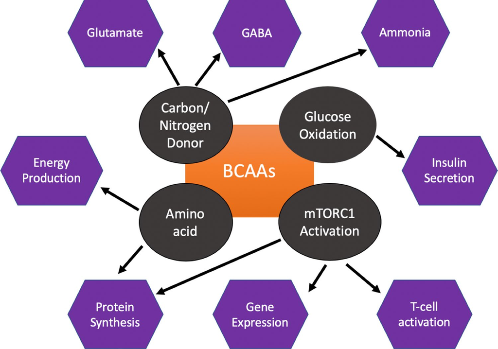

758

S. E. Gruenbaum et al.

**3 Results**

A total of 3594 articles were retrieved from the systematic

literature search. After removing the duplicates, 2045 arti-

cles were then screened (Fig. 2). Of these articles, 2034

were excluded. Of the 11 included articles, the effects of

seizures were tested in one clinical study in children with

refractory epilepsy, as well as in seven animal models of

epilepsy: strychnine (one study), pentylenetetrazole (PTZ;

two studies), fluorothyl (one study), picrotoxin (two stud-

ies), Genetic Absence in Epilepsy in Rats from Strasbourg

(GAERS; one study), kainic acid (KA; two studies) and

methionine sulfoximine (MSO; one study) (Table 1). In

three of the aforementioned studies, a BCAA mixture was

administered; in the other studies, one or more BCAAs

were individually administered (Fig. 3). Branched-chain

amino acids were found to have anticonvulsant effects in

the above-mentioned clinical study, and in five animal

models of epilepsy. The GAERS model exhibited minor

pro-seizure effects of BCAAs. The MSO model dem-

onstrated reduced seizure propagation with short-term

BCAA supplementation, whereas long-term supplementa-

tion worsened seizure propagation and caused neuron loss.

**3.1 Effects of Branched‑Chain Amino Acids (BCAAs)**

**[Administered as a Mixture] on Seizures**

**in Laboratory Animals**

**3.1.1 Methionine Sulfoximine Model**

Methionine sulfoximine has been shown to suppress the

activity of glutamine synthetase (GS) locally in the brain

[34]. In the MSO model of mesial temporal lobe epilepsy

(MTLE), GS is inhibited in the right hippocampal forma-

tion in rats via a long-term intra-hippocampal infusion of

MSO [34]. We recently studied the effects of BCAA sup-

plementation on seizures in 16 MSO-treated rats [35]. The

**Fig. 2** Study flow chart. We

identified 2045 studies by a sys-

tematic review, of which 11 met

our inclusion criteria. In total,

one human study and seven

animal models of epilepsy were

extracted in which the effects

of branched-chain amino acid

administration on seizures were

investigated

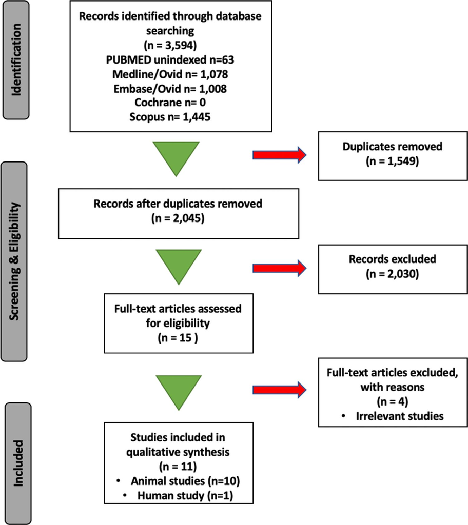

759

Branched-Chain Amino Acids and Seizures

**Table 1** Characteristics of studies included in this systematic review

Author, year (epilepsy

model)

Species Sample size

BCAA

Experimental paradigm

Results

Conclusions

**Preclinical studies**

Jeske, 1974 [44]

(strychnine)

Mouse

5–10 per group

Leucine

Leucine was administered

60 min (100 mg/kg) prior

to SC strychnine adminis-

tration (25 μg/kg)

All seizures were abolished

when leucine was admin-

istered before strychnine

injection

Leucine had anticonvulsant

effects in a strychnine-

induced model of epilepsy

Pinto, 1988 [47]

(PTZ and fluorothyl)

Mouse

Average 14 per group

Valine

1000 mg/kg aspar-

tame ± valine (1000 mg/

kg) was administered

orally 1 h prior to PTZ

(50–75 mg/kg) or fluoro-

thyl (10%)

Valine alone was ineffec-

tive in both models, but

blocked the pro-convulsant

effects of aspartame

Pro-convulsant action of

aspartame was blocked by

valine when given concomi-

tantly

Skeie, 1992 [38]

(picrotoxin)

Rat

10 in the experimental and

control groups, respec-

tively

4% combination of leucine,

isoleucine, and valine

4% BCAAs were admin-

istered IP 2 h prior to

seizure induction with

picrotoxin IP (10 mg/kg)

There was an increased

latency time to seizure

onset in the experimental

group

Injection of a 4% BCAA solu-

tion increased the seizure

threshold to picrotoxin

Skeie, 1994 [39] (picro-

toxin)

Rat

10 per group

Leucine, isoleucine, valine,

or a mixed AA solution

Valine, leucine, or isoleu-

cine (300 mg/kg IP) was

administered 120 min

prior to picrotoxin injec-

tion

The latency time to seizure

onset was increased in

animals pretreated with

BCAAs

Valine, leucine, and isoleucine

increased the seizure thresh-

old to picrotoxin, whereas a

balanced AA solution had

no effect

Dufour, 1999 [46]

(PTZ)

Rat

10 in the experimental and

control groups, respec-

tively

Leucine, isoleucine, valine,

or a mixed AA solution

Leucine, isoleucine, valine,

a mixture of AAs, or saline

(control) was administered

in rats 2 h prior to the

administration of PTZ

The latency to SWD and to

tonic-clonic seizures was

increased in the leucine

and isoleucine groups

Leucine and isoleucine, but

not valine, increased the

latency to absence-like and

tonic-clonic seizures, but

had no effect on the duration

of tonic-clonic seizures

Dufour, 2001 [53, 54]

(GAERS)

Rat

10 per treatment group

Leucine, isoleucine, or

valine

Leucine, isoleucine, valine,

α-KIC, a balanced AA

solution (300 mg/kg IP),

or saline was administered

in GAERS rats

Leucine, isoleucine, valine,

and α-KIC increased

the number of SWD per

20 min. The duration of

SWD was increased only

in the valine and isoleucine

group

BCAAs and α-KIC, when

injected IP, increased the

number of SWD in GAERS

and a minor effect on their

duration

Hartman, 2015 [57]

(KA)

Mouse

8–36 per treatment group

l-Leucine or d-leucine

A single IP injection of l-

or d-leucine (3 mg/kg or

300 mg/kg) was adminis-

tered 3 h before or 15–20

min after KA injection

d- or l-leucine suppressed

seizure activity when

administered before sei-

zure induction. However,

only d-leucine terminated

seizures when adminis-

tered after seizure onset

l- and d-leucine pretreatment

had potent anticonvulsant

effects, but only d-leucine

was effective in terminating

seizures when administered

after seizure onset

760

S. E. Gruenbaum et al.

**Table 1** (continued)

Author, year (epilepsy

model)

Species Sample size

BCAA

Experimental paradigm

Results

Conclusions

Holden, 2017 [58] (KA)

Mouse

13

d-Leucine

d-Leucine (1.5% w/v) was

administered in the drink-

ing water in animals with

KA-induced seizures

d-Leucine treatment

decreased the number of

days with seizures in the

dark cycle and the seizure

frequency in the light cycle

d-Leucine is protective against

seizures in a light-dependent

manner

Gruenbaum, 2019 [35]

(MSO)

Rat

8 in each (experimental and

control) group

4% mixture of leucine,

isoleucine, and valine

A 4% BCAA mixture in

water was administered in

drinking water ad libitum

to MSO infused animals

for 21 days

In BCAA-treated rats,

decrease in relative percent

of convulsive seizures

third week, respectively

Long-term BCAA supplemen-

tation facilitated the spread

of seizures from the hip-

pocampus to motor cortex,

which was associated with

an increase in seizure-asso-

ciated neuron loss

**Human studies**

Evangeliou, 2009 [60]

Human

17

A mixture of leucine, iso-

leucine, and valine

Children (aged 2–7 years)

with refractory epilepsy

were administered an oral

mixture of BCAAs daily

for 6–12 months along

with a KD (started 6–24

months prior)

The addition of BCAAs

to the ketogenic diet sig-

nificantly reduced seizure

activity compared with the

KD alone

BCAAs may increase the

anticonvulsant effectiveness

of the KD

*AA* amino acid, *α-KIC* α-ketoisocaproate, *BCAA* branched-chain amino acid, *GAERS* genetic absence epilepsy rat from Strasbourg, *h* hours, *IP* intra-peritoneally, *KA* kainic acid, *KD* ketogenic

diet, *min* minutes, *MSO* methionine sulfoximine, *PTZ* pentylenetetrazole, *SC* subcutaneous, *SWD* spike-wave discharge

761

Branched-Chain Amino Acids and Seizures

MSO-treated rats were randomized to receive either unre-

stricted access to water or a 4% BCAA solution in water,

and seizure activity was monitored for a period of 21 days.

Although BCAA ingestion was ineffective in reducing the

frequency of convulsive and non-convulsive seizures, short-

term BCAA ingestion reduced seizure propagation (reflected

by a reduction in the relative percent of convulsive seizures),

while long-term oral supplementation with BCAAs worsens

seizure propagation (reflected by an increase in the relative

percent of convulsive seizures) and seizure-associated neu-

ron loss. The study suggests that the effect of BCAAs on

seizure propagation in MTLE might be dependent on the

duration of exposure.

**3.1.2 Picrotoxin Model**

The chemo-convulsant picrotoxin antagonizes the GABA-

benzodiazepine receptor complex and is a noncompetitive

channel blocker for GABAA Cl<sup>−</sup> channels [36]. The result-

ing reduction in Cl<sup>−</sup> permeability inhibits the target neuron.

Picrotoxin also antagonizes GABAC receptors allosterically

[37]. After an intraperitoneal (IP) injection of picrotoxin,

mice exhibit tonic seizures that follow a brief latent period,

which facilitates the study of novel treatments on the seizure

threshold [38].

We identified two studies that investigated the effect of

BCAA administration prior to picrotoxin-induced seizures.

In the first study [38], 20 male Wistar rats were randomized

to receive either an IP injection with a 4% BCAA solution or

placebo (8 mL/kg), and receive an IP injection of picrotoxin

(10 mg/kg) 120 min later. Ten rats were injected with the

4% BCAA solution, which contained 1.24 g valine, 1.38 g

leucine, and 1.38 g isoleucine for every 100 mL. The authors

reported a significant increase in the latency time between

the picrotoxin injection and seizure onset in the rats pre-

treated with BCAAs. The mean latency time was 11.2 min

for the BCAA-treated group and 8.3 min for the placebo-

treated group (*p* < 0.03). Because the seizure threshold to

picrotoxin was increased by BCAAs, the authors proposed

that effect of BCAAs might be due to its interactions with

the GABA-benzodiazepine receptor complex. A second

study further examined this relationship [39], and investi-

gated the effect of individual BCAAs on the seizure thresh-

old to picrotoxin (described below).

**3.2 Effects of BCAAs (Administered Individually)**

**on Seizures in Laboratory Animals**

**3.2.1 Strychnine Model**

Intraperitoneal or subcutaneous injection of strychnine in

rodents results in acute generalized tonic-clonic seizures [40,

41]. Strychnine acts as a selective competitive antagonist

of chloride channel-associated postsynaptic glycine recep-

tors, thereby blocking the inhibitory action of glycine [42].

The convulsions generated with this model are refractory to

most standard antiepileptic drugs [43] and exhibit tonic or

tonic-clonic seizure patterns. The model provides a reliable

method to assess the effects of novel antiepileptic drugs by

quantifying the number of spontaneous seizures before and

after treatment.

We identified one study in which the anticonvulsive

effects of amino acid derivatives of 4-aminoantipyrine on

strychnine-induced convulsions were investigated [44]. Male

Swiss mice (weight 18–20 g, *n* = 5–10) received subcutane-

ous injections of strychnine (25 μg/20 g) to induce seizures.

Various amino acid derivatives were injected subcutaneously

10, 30, and 60 min prior to seizure induction to observe

for potential anticonvulsive effects. The authors demon-

strated that subcutaneous injections of l-leucine (100 mg/

kg) and the α-methyl ester of 4-gamma-glutamyl-antipy-

rine (100 mg/kg) 10 and 60 min prior to seizure induction

**Fig. 3** Overview of studies

that investigated the effects of

branched-chain amino acids

(BCAAs) on seizure activ-

ity. From a total of 11 studies,

two studies demonstrated that

BCAAs exhibited pro-convul-

sant effects, whereas the other

nine studies demonstrated

anticonvulsant effects. Three

studies used a BCAA mixture in

the experimental group, and the

remaining studies investigated

the effects of leucine, valine,

and isoleucine when adminis-

tered individually

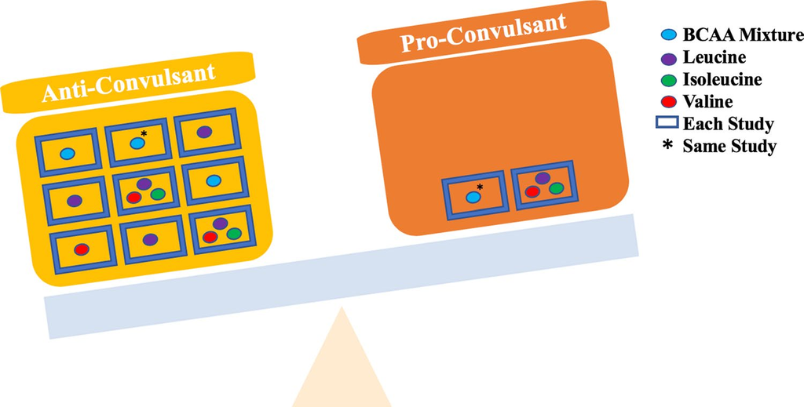

762

S. E. Gruenbaum et al.

completely abolished convulsions, whereas dl-valine and

dl-leucine failed to demonstrate anticonvulsive effects.

**3.2.2 Pentylenetetrazole Model**

Pentylenetetrazole is a GABAA receptor antagonist that is

used to induce both acute seizures and chemical kindling in

rodents. Pentylenetetrazole administered via the IP or subcu-

taneous route at doses of 60–100 mg/kg results in myoclonic

jerks, clonus and tonic extensions after 5–9 min. Repeated

administrations at sub-threshold doses of 20–40 mg/kg can

induce the kindling phenomenon, and can thereby serve as

a chronic epilepsy model [45].

We identified two studies that examined the effect of

BCAAs on PTZ-induced seizures. The first study [46] inves-

tigated whether the administration of BCAAs or the ketoacid

of leucine (α-ketoisocaproic acid; α-KIC) 2 h prior to sei-

zure induction would modulate the effect of absence-like and

tonic-clonic seizures. A total of 20 non-epileptic, 5-month-

old male Wistar rats were subcutaneously injected with PTZ

weekly (40 mg/kg). This regimen resulted in absence-like

and spike-and-wave discharges (SWD) followed by parox-

ysmal EEG activity and tonic-clonic seizures. The ten rats

in the experimental group received pretreatment with injec-

tions of leucine, isoleucine, valine, or α-KIC (each 300 mg/

kg) 2 h before administration of PTZ. The ten rats in the

control group received saline injections along with a bal-

anced mixture of amino acids, Vamin<sup>®</sup> (Pharmacia, Canada

Ltd., Montreal, QC, Canada; 300 mg/kg). The primary out-

come measures in this experiment were latency to the first

SWD or tonic-clonic seizure, the number of SWD episodes

per minute of recording before the onset of the tonic-clonic

phase, the total duration of the period of SWD preceding the

occurrence of the tonic-clonic seizure, and the total dura-

tion of the convulsive seizure. Pretreatment with leucine

or isoleucine significantly increased the latency to the first

SWD (+ 101–104%), the latency to the tonic-clonic seizure

(+ 53–62%), and the duration of the SWD period preceding

the convulsive seizure (+ 39–62%). However, while leucine

and isoleucine delayed the occurrence of tonic-clonic sei-

zures, they had no effect on seizure duration. Valine, α-KIC,

and the commercial mixture of amino acids had no effect on

seizures. The authors noted that the difference in efficacy

between valine and leucine/isoleucine may be due to the

relatively low affinity of valine to the transport system of

neutral amino acids across the BBB [18].

A second study [47] demonstrated that valine was

effective in blocking the pro-convulsive effects of aspar-

PTZ (50–75 mg/kg), the mice were administered valine

(1000 mg/kg) and/or aspartame (1000 mg/kg) orally. In

mice receiving treatment with only aspartame (1000 and

2000 mg/kg), the authors demonstrated a significant increase

in the percentage of animals that experienced PTZ-induced

seizures (*p* < 0.05). Interestingly, the pro-convulsant effects

of aspartame were blocked in mice that received concomi-

tant administration of valine (1000 mg/kg). However, when

administered alone, valine had no effect on seizure fre-

quency. The authors found that treatment with aspartame

elevated levels of phenylalanine in the brain. In this case,

valine effectively antagonized the transport of phenylalanine

into the brain.

**3.2.3 Flurothyl Model**

With repeated exposure to flurothyl, a GABAA recep-

tor antagonist, mice demonstrate spontaneous seizures

and generalized clonic seizures that remit within 1 month

[48]. Animals are placed in an airtight chamber, where the

volatile flurothyl vapors are inhaled. Absence-like seizures

and partial seizures typically occur after short exposure to

flurothyl, while clonic and tonic-clonic seizures occur after

longer exposures [49]. Findings suggest that the mechanism

for flurothyl-induced seizures is in part mediated by the

benzodiazepine-binding site of the GABA-benzodiazepine

receptor complex [50].

We identified a study that examined the pro-convulsive

effects of aspartame on flurothyl-induced seizures in male

CD-I mice (average *n* = 14/group) [47]. Valine (1000 mg/

kg) and/or aspartame (1000 mg/kg) was administered orally

1 h prior to seizure induction with flurothyl inhalation (10%

solution in 95% ethanol, 0.05 mL/min). The authors found

that doses of 1000, 1500, or 2000 mg/kg of aspartame sig-

nificantly reduced the time to clonic seizure (395, 381, and

339 s; *p* < 0.05). As with the PTZ model above, concurrent

administration of valine (1000 mg/kg) blocked the pro-con-

vulsant effects of aspartame and prevented a reduction in the

time to clonic seizures.

**3.2.4 Picrotoxin Model**

Following the previously described study with the picrotoxin

model of epilepsy [38], a second study [39] was performed

to investigate the effects of individual BCAAs on picrotoxin-

induced seizures. Fifty male Wistar rats were divided into

five groups of ten rats, and each group received a different

pretreatment 120 min before the injection of picrotoxin. Rats

were randomized to receive either an IP injection with valine

(300 mg/kg), leucine (300 mg/kg), isoleucine (300 mg/kg),

significant increase in the latency time to seizure onset com-

pared with the placebo and balanced amino acid solution.

763

Branched-Chain Amino Acids and Seizures

**3.2.5 Genetic Absence Epilepsy in a Rat Model**

The GAERS model utilizes a strain of rats that exhibits

recurrent non-convulsive seizures, accompanied by bilateral

and synchronous SWD by electroencephalography (EEG)

[51]. Drugs that are effective against absence seizures in

humans have been shown to reduce SWD in GAERS in a

dose-dependent manner. However, drugs that are used for

convulsive and focal seizures have no effect on seizures in

GAERS. Findings suggest that the absence seizures from

GAERS result from disturbances in the thalamocortical cir-

cuitry [52].

We identified a study (published in two independent

papers) that investigated the effects of BCAAs on epileptic

seizures in GAERS [53, 54]. Groups of ten GAERS rats

were administered saline or 300 mg/kg of leucine (22 mg/

kg), isoleucine (16.7 mg/kg), valine (18.2 mg/kg), α-KIC, or

a balanced amino acid solution via IP injections. Electroen-

cephalography was recorded for 40 min during each hour for

5 consecutive hours, and the cumulative duration of SWD

was measured during 20-min periods of EEG recording.

Injections of leucine, isoleucine, valine, and α-KIC resulted

in an increased number of SWD per 20 min. The duration

of SWD was not affected by a single injection of leucine or

α-KIC. Valine increased the duration of SWD at 260 min

post-injection, and isoleucine increased the duration of

SWD at 220 min and 260 min post-injection. The balanced

amino acid solution had no effect on the number of dura-

tions of SWD. The experiment demonstrated that BCAAs

and α-KIC, when injected intraperitoneally, increased the

number of SWD in GAERS and had a minor effect on their

duration.

**3.2.6 Kainic Acid Model**

Kainic acid is a cyclic analog of l-glutamate that acts as

a potent agonist to the AMPA/kainate class of glutamate

receptors [55]. Infusion with KA can result in neurodegen-

eration and seizures. Kainic acid can be used to create a

rodent model that closely mimics temporal lobe epilepsy in

humans, with a latent period and subsequent spontaneous

seizures, which are refractory to many antiepileptic drugs

[56]. The KA model generates focal-onset (localization-

related) seizures, which contribute to many cases of epilepsy

in adults [57].

Two recent studies examined the anti-seizure effects of

l-leucine in the KA model of epilepsy. In the first study [57],

5-week-old C57BL/6 mice were administered an IP injection

of KA. The mice were administered a single IP injection of l-

or d-leucine (3 mg/kg or 300 mg/kg) 3 h before or 15–20 min

after KA injection. The study demonstrated that a single low

dose of l-leucine injected 3 h prior to KA-induced seizures

potently suppressed seizure activity, whereas the high dose

only had intermediate anticonvulsant effects. d-Leucine also

suppressed seizure activity in a manner at least as effective

as l-leucine. While both forms of leucine provided potent

anticonvulsant effects as pretreatments, only d-Leucine effec-

tively terminated seizures, even when administered after the

seizure onset. The authors noted that the mechanism of action

of d-leucine is unclear because there is no known function for

endogenous d-leucine in eukaryotic biology, and that d-leucine

is not incorporated into mammalian proteins.

Another recent study investigated the effects of d-leu-

cine on KA-induced spontaneous seizures [58]. Mice were

administered an IP injection of KA (25–100 mg/kg body

weight until the mouse went into status epilepticus), and

EEG was monitored for 4 weeks before, after, and during

administration of ad libitum d-leucine (1.5% w/v) in the

drinking water. While no differences were observed in the

overall number of seizure days or frequency of seizures,

d-leucine protected against seizures during the dark cycle.

The seizures recurred during the dark cycle for the 4 weeks

after the d-leucine treatment was withdrawn.

**3.3 Effect of BCAA Mixture on Seizures in Humans**

The ketogenic diet can be a useful adjunct in the treatment

of medically refractory epilepsy, especially in children [59].

In one study [60], 17 children aged 2–7 years and diagnosed

with intractable epilepsy were administered an oral mixture

of BCAAs daily for 6–12 months in addition to the ketogenic

diet, which was initiated 6–24 months prior. One hundred

grams of the supplementary BCAA mixture comprised

45.5 g leucine, 30 g of isoleucine, and 24.5 g of valine.

Patients were started with a daily dose of 5 g mixed in food

or beverages, with weekly increments of 5 g up until a maxi-

mum dosage of 20 g/day. Over the course of the experiment,

the addition of BCAAs to the ketogenic diet resulted in a

significant reduction in seizure frequency. Three patients

experienced a complete cessation of seizures, and two other

patients experienced an additional reduction in seizures

from 70% on the ketogenic diet to 90%. Two patients on

the ketogenic diet experienced a marked improvement from

50% and 60% reductions before BCAAs supplementation to

80% and 90% reductions following BCAA administration.

Side effects were reported to be minimal, with three patients

reporting a slight but transient increase in heart rate at the

beginning of treatment.

**4 Discussion**

**4.1 Possible Mechanism of BCAAs on Seizures**

In this systematic review, we identified 11 studies that exam-

ined the effects of BCAA administration on seizures. One

764

S. E. Gruenbaum et al.

of these studies was conducted in children with medically

refractory epilepsy, and the remaining ten studies were con-

ducted in seven animal models of epilepsy, including the

strychnine, PTZ, fluorothyl, picrotoxin, GAERS, KA, and

MSO models. With the exception of the GAERS model of

absence seizures and long-term BCAA supplementation in

the MSO model, all other studies demonstrated anticon-

vulsant properties of BCAAs. Although the mechanisms

by which BCAAs impact seizures are complex and poorly

understood, several potential mechanisms have been sug-

gested and are reviewed here.

**4.2 Proposed Anticonvulsant Effects of BCAAs**

It has been suggested that BCAAs exert their anticonvul-

sant effects by affecting neuronal excitation and inhibition,

specifically by enhancing the metabolism and clearance of

brain glutamate, as well as facilitating GABA synthesis

and GABAergic neurotransmission (summarized in Fig. 4).

Chronic elevation of glutamate in the extracellular compart-

ment of the brain has been implicated as a key pathophysi-

ological cause of epileptic brain damage and seizures [6,

9, 61]. Branched-chain amino acids are thought to have

several effects on glutamate metabolism and neurotrans-

mission. First, there is evidence that BCAAs might reduce

seizure activity by decreasing the neuronal glutamate levels

available for synaptic release [53]. Blood-derived BCAAs

are rapidly taken up astrocytes, where they transaminate

α-ketoglutarate, thereby producing glutamate and branched-

chain ketoacids (BCKAs). Because BCKAs are poorly oxi-

dized in astrocytes, they are transported out of the astro-

cyte to the extracellular fluid, where they are taken up by

neurons. In the neuron, BCKAs are transaminated back to

BCAAs in a reaction that consumes glutamate [54, 60, 62,

63]. In this manner, BCAAs decrease the neuronal glutamate

available for subsequent synaptic release (Fig. 4, reaction 1).

Second, it is thought that BCAAs facilitate the clear-

ance of glutamate from the brain. The astrocytic glutamate

that is produced from the transamination of α-ketoglutarate

by BCAAs is rapidly converted to glutamine by GS [64].

Depending on the energy needs of the neuron, the newly

formed glutamine is either taken up by neighboring neurons,

where it is packaged into vesicles for excitatory neurotrans-

mission, or is rapidly cleared from the brain via transport

to the blood [65, 66]. Moreover, BCAAs may facilitate the

clearance of glutamine from the brain via obligate exchange

transporters, by which BCAA influx from the blood to the

brain is equal and opposite to glutamine efflux from the

brain to the blood [67]. In summary, the net effect of BCAA

uptake into the brain is that it facilitates both the degrada-

tion of neuronal glutamate and the clearance of astrocytic

glutamate in the form of glutamine (Fig. 4, reaction 2).

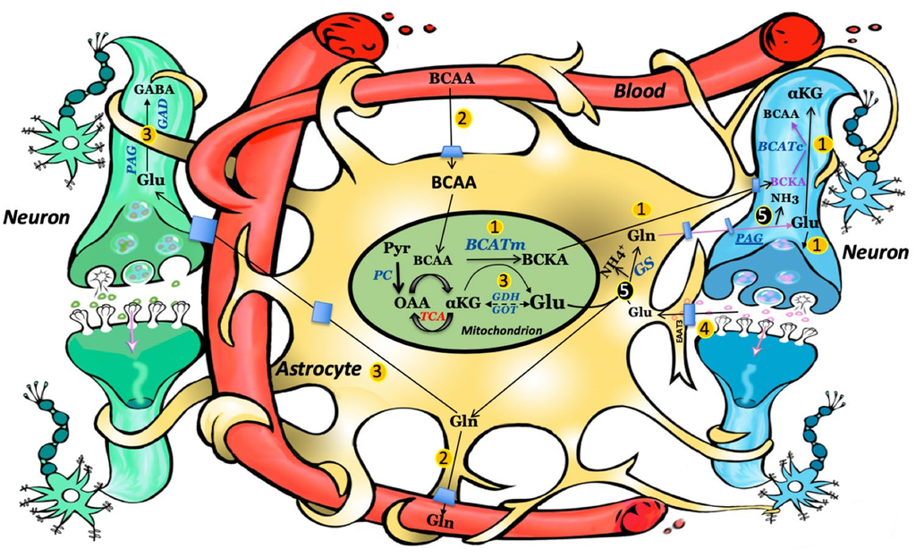

**Fig. 4** Branched-chain amino acid (BCAA)-glutamate-glutamine

shuttle, and the proposed mechanisms underlying the effects of

BCAAs on seizures. Anticonvulsant effects: (1) decrease in neu-

ronal glutamate concentration; (2) increased glutamate clearance

via glutamine, BCAA obligate transport; (3) increased gamma-

aminobutyric acid (GABA) production in GABAergic neuron; and

(4) increased uptake of extracellular glutamate via excitatory amino

acid transporter 3 (EAAT3). Pro-convulsant effects: (5) increased

ammonia production. *aKG* alpha-ketoglutaric acid, *BCATc* cytoplas-

mic branched-chain amino acid transaminase, *BCATm* mitochondrial

branched-chain amino acid transaminase, *BCKA* branched-chain

alpha-ketoacid, *GAD* glutamic acid decarboxylase, *GDH* gluta-

mate dehydrogenase, *Gln* glutamine, *Glu* glutamate, *GOT* glutamic

oxaloacetic transaminase, *GS* glutamine synthetase, *NH**3* ammonia,

*OAA* oxaloacetate, *PAG* phosphate-activated glutaminase, *PC* pyru-

vate carboxylase, *Pyr* pyruvate, *TCA* tricarboxylic acid cycle

765

Branched-Chain Amino Acids and Seizures

There is further evidence that the anticonvulsant effects

of BCAAs may be GABA mediated, either by direct stimu-

lation of GABA receptors or by increasing GABA produc-

tion. The administration of BCAAs are thought to favor the

production of GABA by inhibiting both glutamate dehy-

drogenase activity [68, 69] and glutamate oxaloacetate

transaminase [59], two enzymes that play a key role in the

degradation of astrocytic glutamate. In this way, glutamine

production from glutamate is favored over α-ketoglutarate

production, and the newly formed glutamine can then be

shuttled to GABAergic neurons where it can be used for

GABA synthesis (Fig. 4, reaction 3). Moreover, studies

have demonstrated that 5-aminovaleric acid, a valine analog

with anticonvulsant effects [70], facilitates GABA-mediated

neurotransmission by direct interaction with GABAB recep-

tors [71, 72], by blocking glial uptake of extracellular fluid

GABA [73] or by inhibiting GABA degradation [72].

The ketogenic diet effectively reduces the frequency and

severity of seizures, and is used as an adjunct therapy in

treating patients (especially children) with epilepsy [74, 75].

The BCAAs, in combination with the ketogenic diet, was

shown to be more effective in reducing the frequency of

epileptic seizures than the ketogenic diet alone [60]. It is

unclear from this study whether the anticonvulsant effects

of BCAAs resulted from synergism with the ketogenic diet,

or whether their actions were mediated by an entirely differ-

ent mechanism. Leucine is a known ketogenic amino acid,

and its degradation produces the anticonvulsant ketones

acetoacetate and β-hydroxybutyrate [76]. Moreover, during

ketosis, plasma and brain concentrations of BCAAs mark-

edly increase, causing some experts to speculate that BCAAs

and the ketogenic diet share key anticonvulsant mechanisms

[59, 77–79]. It is important to note, however, that several

studies have observed that the BCAA-induced reduction in

seizures occurs regardless of the level of ketosis [57], sug-

gesting that BCAAs may have anticonvulsant properties that

are independent of their ketogenic effects.

Another mechanism by which BCAA is thought to exert

its anticonvulsant effects is by promoting glucose homeosta-

sis. Studies have shown that BCAAs are involved in critical

nutrient signaling pathways in the hypothalamus, and play

an important role in maintaining a state of metabolic bal-

ance [80]. Leucine produces a robust synergetic effect with

insulin to regulate glucose levels, and isoleucine and valine

suppress endogenous glucose production [81]. Importantly,

both hyperglycemia and hypoglycemia can induce seizure

activity or increase seizure susceptibility in animals and

humans [82–84]. Clinical studies have shown that the peo-

ple with hyperglycemia have an increased predisposition to

seizures [85, 86], possibly by attenuating potassium (adeno-

sine triphosphate) channels [87]. Moreover, both in vivo and

in vitro studies have demonstrated that a threshold blood

glucose concentration is necessary for adequate synaptic

transmission [83]. In the presence of seizures, an increase

in BCAA concentrations might result in an improved meta-

bolic balance, followed by a subsequent reduction in seizure

activity.

Last, BCAAs might modulate seizure activity by interact-

ing with mammalian target of rapamycin (mTOR) recep-

tors. Mammalian target of rapamycin is an atypical serine/

threonine kinase, which is present in two different com-

plexes: mammalian target of rapamycin complex 1, which

is inhibited by rapamycin, and mammalian target of rapa-

mycin complex 2, which is insensitive to rapamycin. It is

well known that BCAAs are potent activators of the mTOR

receptor, thereby initiating a cascade of cell signaling path-

ways [88–90]. Although the activation of the mTOR signal-

ing pathway is thought to play an important role in several

cellular and molecular processes that affect neuronal excit-

ability and seizure activity, the exact mechanism by which

mTOR activation affects seizures is poorly understood [91].

Studies have shown that activation of the mTOR signaling

cascade stimulates the neuronal uptake of extracellular glu-

tamate [92] via excitatory amino acid transporter 3 [93],

thereby facilitating the clearance of extracellular glutamate

(Fig. 4, reaction 4). The mechanisms by which BCAA-medi-

ated mTOR activation modulates seizure activity warrants

further study.

**4.3 Pro‑Convulsant Effects in the Genetic Absence**

**in Epilepsy in Rats from Strasbourg Model**

**and the Methionine Sulfoximine Model**

The study conducted in the GAERS model of absence sei-

zures demonstrated a slight pro-seizure effect after BCAA

administration. The injection of leucine and α-KIC in the

GAERS model resulted in a decrease in intracerebral gluta-

mate levels. The authors postulated that a decrease in gluta-

matergic neurotransmission would thereby promote GABAe-

rgic neurotransmission, which is known to cause seizures in

the GAERS model [52]. Moreover, the study demonstrated

that leucine administration activated the urea cycle in the

thalamus, which reflects an increase in ammonia production

in the brain [54, 94]. Ammonia is inherently neurotoxic, and

further induces cellular apoptosis by increasing the extracel-

lular fluid (ECF) levels of potassium in the brain [95], which

is also thought to play an important role in absence seizures

in the GAERS model.

In the MSO model of MTLE, long-term BCAA supple-

mentation worsened the spread of seizures from the hip-

pocampus to the motor cortex, as evidenced by an increase

in the relative percent of convulsive seizures. In the pres-

ence of the GS deficiency that characterizes this model,

high levels of BCAAs in the brain are thought to result in

increased extracellular glutamate and slowed glutamate-glu-

tamine cycling [9, 96, 97], increased ammonia production

766

S. E. Gruenbaum et al.

(Fig 4, reaction 5) [54, 98], decreased ammonia clearance

[98], and perturbed neurotransmitter concentrations [99].

These effects might also account for the neuron loss asso-

ciated with long-term supplementation of BCAAs in this

model. Seizure-induced neuron loss, along with the elevated

ammonia and elevated glutamate levels typically present in

MTLE [100], might explain the increased seizure propaga-

tion observed with long-term BCAA exposure.

The pro-convulsant effects of BCAAs can also be

explained by a decreased synthesis of biogenic amines DA,

5-HT, and NE in the setting of high peripheral BCAA levels.

Monoamines (e.g., 5-HT and catecholamines such as DA

and NE) are known to be protective against seizure activ-

ity, while 5-HT and DA dysregulation has been implicated

in epilepsy. Many studies have suggested that serotonergic

and dopaminergic neurotransmission are essential in control-

ling seizure susceptibility [101]. Moreover, some commonly

used antiepileptic drugs are thought to work by increasing

the levels of 5-HT and DA [15, 102, 103]. Selective sero-

tonin reuptake inhibitors, which increase the level of sero-

tonin available at the synapse, have also shown promise in

treating refractory epilepsy [104, 105]. Similarly, the use of

vagal nerve stimulation to treat refractory epilepsy exploits

the anticonvulsant properties of NE [106]. The decreased

synthesis of these neurotransmitters in the setting of high

BCAA concentrations can be accounted for by a decrease

in ArAAs transport into the brain [11]. Dopamine, 5-HT,

and NE are synthesized from the ArAAs tryptophan, tyros-

ine, and phenylalanine [17, 107, 108], which together with

BCAAs and other neutral amino acids, compete for trans-

port across the BBB by the same transport system. Although

these transporters are typically saturated at physiological

plasma concentrations [18, 19, 109], a sudden increase in

peripheral BCAA concentrations that follows a short-term

BCAA administration can increase the uptake of BCAAs

into the brain, thereby decreasing the uptake of ArAAs [20].

Consequently, a reduction in the concentration of precur-

sor amino acids (tryptophan, tyrosine, and phenylalanine)

results in a reduction in the synthesis of 5-HT, DA, and NE

[110–112], which has been associated with neuronal loss

[113, 114]. Therefore, in the aforementioned MSO study

[35], the pro-convulsant effects and neuronal loss observed

with long-term BCAA supplementation might be explained

by a reduction in biogenic amine neurotransmitter synthesis.

**4.4 Implications for BCAA Treatment in Human**

**Epilepsy**

Although some animal models of epilepsy and one human

study have demonstrated potent anti-seizure effects of

BCAAs, many questions remain unanswered regarding

optimal dosing and duration of BCAA treatment, and

which epilepsy conditions might benefit most. Notably,

the use of BCAAs in treating epilepsy should be cautioned

by recent studies that have shown neurotoxic effects when

high concentrations of BCAAs are present in the brain,

particularly in conditions where BCAA metabolism or

glutamate clearance is perturbed [27, 115, 116]. Based

on these observations, taken together with the effects of

physiological conditions.

First, the anticonvulsant effects (or pro-convulsant effects

in the case of the GAERS model) of BCAAs are likely

dependent on the efficient uptake from the blood to the brain.

For example, studies have shown that compared with leucine

and isoleucine, valine has a five to ten-fold lower affinity for

the large neutral amino acid transporters (LNATs) through

which BCAAs are transported into the brain [18]. As such,

valine has less anticonvulsant effects than leucine or iso-

leucine in animal models of epilepsy [46, 47]. Moreover,

although PTZ administration results in seizures, PTZ also

facilitates the uptake of leucine from the blood to the brain

[117], where it can inhibit seizure activity. This may in part

explain the potent anticonvulsive effects of leucine in the

context of PTZ-induced seizures.

Second, the anticonvulsant effects of BCAAs are likely

dependent on effective BCAA metabolism, thereby pre-

venting the build-up of high concentrations of BCAAs in

the brain. This is especially evident in maple syrup urine

disease, in which decreased BCAA metabolism results in

increased BCAAs and seizures [31]. When BCAAs are pre-

sent in high concentrations owing to inefficient metabolism,

they have deleterious effects on brain energy metabolism

[118] and brain development [119] Branched-chain amino

acids have been shown to stimulate ammonia production in

the brain [54, 94], which is neurotoxic as discussed above.

Moreover, high concentrations of BCAAs result in the accu-

mulation of toxic metabolites that induce oxidant cortical

injury [120].

Third, the anticonvulsant effects are likely dependent on

efficient glutamate metabolism and clearance in the ECF.

Interestingly, although BCAAs contribute to glutamate

production in astrocytes, the peripheral injection of BCAAs

does not normally increase ECF glutamate levels in the brain

[53]. Rather, the newly synthesized astrocytic glutamate is

rapidly converted to the biologically inert amino acid glu-

tamine, which either enters the glutamate-glutamine cycle

or is transported back to the blood. In conditions where

glutamate production from BCAAs are increased (i.e., in

glioma) or glutamate clearance is perturbed (i.e., amyo-

trophic lateral sclerosis), BCAA administration has indeed

resulted in neurotoxic effects [121]. Importantly, some

forms of medically refractory epilepsy such as MTLE are

characterized by a deficiency in GS and slowed glutamate-

glutamine cycling [9]. This might explain why long-term

767

Branched-Chain Amino Acids and Seizures

BCAA supplementation worsened seizure propagation and

neuron loss in the MSO model of MTLE.

Fourth, the anticonvulsant properties of BCAAs can be

attributed to their role in metabolic regulation via glucose

homeostasis. A reduction in seizure threshold has been

associated with perturbed glucose levels [122], and case

studies have described non-ketotic hyperglycemic seizures

in humans [123, 124]. Increased BCAAs, via hypothalamic

signaling [125], can help promote glucose homeostasis

and improve energy balance. Moreover, BCAAs, together

with insulin, can stimulate mammalian target of rapamycin

complex 1 signaling pathways to modify messenger RNA

translation [126]. This process likely functions as an ana-

bolic signal to alter tissue growth in areas of high metabolic

activity (e.g., within a seizure focus) [125].

**5 Conclusions**

Epilepsy often results in significant individual disability and

has a high negative economic impact on public health. In up

to 40% of patients, seizures recur despite medical therapy,

highlighting the need for the development of better meth-

ods of treating seizures. In recent years, BCAAs have been

shown to have several effects in the brain, and can either

stimulate or inhibit seizures. The mechanistic link between

BCAAs and seizure activity has not been fully elucidated.

Here, we systematically reviewed ten animal studies and

one human study that investigated the effects of BCAAs on

seizure activity. In most epilepsy models and in humans,

BCAAs were shown to have potent anticonvulsant effects

while in the GAERS epilepsy model and long-term BCAA

treatment in the MSO model, BCAAs had pro-convulsant

effects. The effects of BCAAs on seizure activity likely

reflects the numerous and complex cellular pathways by

which BCAAs are thought to act, including biogenic amines,

glucose, glutamate, GABA, and ammonia homeostasis in the

brain. Moreover, the different effects of BCAAs on seizures

might reflect differences in the complex pathophysiological

mechanisms of the underlying seizure disorder. In conditions

in which BCAAs have inhibited seizure activity, the anti-

convulsant effects of BCAAs are likely dependent on effec-

tive uptake of BCAAs from the blood to the brain, effective

BCAA metabolism in the brain, effective metabolism and

clearance of extracellular glutamate in the brain, and tighter

glucose homeostasis. Future studies should further elucidate

the mechanisms by which BCAAs affect seizure activity.

Ultimately, BCAA-associated metabolic pathways might be

useful therapeutic targets in the treatment of some medically

refractory epilepsy conditions.

**Acknowledgements** The authors gratefully acknowledge Garrett

Sendlewski (Yale Media Laboratory Associate) for his outstanding

illustrative work for Fig. 4, and Alexandria Brackett, MA, MLIS (Clini-

cal Librarian) for her assistance in performing the literature review.

**Compliance with Ethical Standards**

**Funding** Tore Eid and Roni Dhaher are supported by grants from

the National Institute of Health (NIH): NINDS K08 NS058674 and

R01 NS070824. Tore Eid is supported by an Innovator Award from

Citizens United for Research in Epilepsy (CURE). Shaun E. Gruen is

supported by grants from the NIH: T32 GM086287 and the Founda-

tion of Anesthesia Education and Research (FAER). This work was

also made possible by a grant from the National Center for Advancing

Translational Science (NCATS; UL1 TR000142), a component of the

NIH and the NIH roadmap for Medical Research. Its contents are solely

the responsibility of the authors and do not necessarily represent the

official view of the NIH.

**Conflict of interest** Shaun E. Gruenbaum, Eric C. Chen, Mani Ratnesh

S. Sandhu, Ketaki Deshpande, Roni Dhaher, Denise Hersey, and Tore

Eid have no conflicts of interest that are directly relevant to the content

of this article.

**References**

1. Chang BS, Lowenstein DH. Epilepsy. N Engl J Med.

2003;349(13):1257–66.

2. ILAE Commission Report. The epidemiology of the epilepsies:

future directions. International League Against Epilepsy. Epilep-

sia. 1997;38(5):614–8.

3. Begley CE, Famulari M, Annegers JF, Lairson DR, Reynolds TF,

Coan S, et al. The cost of epilepsy in the United States: an esti-

mate from population-based clinical and survey data. Epilepsia.

2000;41(3):342–51.

4. de Lanerolle NC, Lee TS, Spencer DD. Histopathology of human

epilepsy. In: Noebels JL, Avoli M, Rogawski MA, Olsen RW,

Delgado-Escueta AV, editors. Jasper’s basic mechanisms of the

epilepsies. 4th ed. Bethesda: National Center for Biotechnology

Information; 2012.

5. Annegers J. The treatment of epilepsy: principles and practice.

2nd ed. Baltimore: Williams and Wilkins; 1996.

6. Eid T, Gruenbaum SE, Dhaher R, Lee TW, Zhou Y, Danbolt

NC. The glutamate-glutamine cycle in epilepsy. Adv Neurobiol.

2016;13:351–400.

7. McCormick DA, Contreras D. On the cellular and network bases

of epileptic seizures. Annu Rev Physiol. 2001;63:815–46.

8. Zimmerman G, Njunting M, Ivens S, Tolner EA, Behrens CJ,

Gross M, et al. Acetylcholine-induced seizure-like activity and

modified cholinergic gene expression in chronically epileptic

rats. Eur J Neuurosci. 2008;27(4):965–75.

9. Eid T, Thomas MJ, Spencer DD, Runden-Pran E, Lai JC,

Malthankar GV, et al. Loss of glutamine synthetase in the human

epileptogenic hippocampus: possible mechanism for raised extra-

cellular glutamate in mesial temporal lobe epilepsy. Lancet.

2004;363(9402):28–37.

10. Yudkoff M. Brain metabolism of branched-chain amino acids.

Glia. 1997;21(1):92–8.

11. Fernstrom JD. Branched-chain amino acids and brain function.

J Nutr. 2005;135(6):1539S–46S.

12. Matsuo H, Tsukada S, Nakata T, Chairoungdua A, Kim DK, Cha

SH, et al. Expression of a system L neutral amino acid transporter

at the blood–brain barrier. Neuroreport. 2000;11(16):3507–11.

768

S. E. Gruenbaum et al.

13. Takanaga H, Mackenzie B, Peng JB, Hediger MA. Charac-

terization of a branched-chain amino-acid transporter SBAT1

(SLC6A15) that is expressed in human brain. Biochem Biophys

Res Commun. 2005;337(3):892–900.

14. Giorgi FS, Pizzanelli C, Biagioni F, Murri L, Fornai F. The role

of norepinephrine in epilepsy: from the bench to the bedside.

Neurosci Biobehav Rev. 2004;28(5):507–24.

15. Kumar U, Medel-Matus JS, Redwine HM, Shin D, Hensler JG,

Sankar R, et al. Effects of selective serotonin and norepinephrine

reuptake inhibitors on depressive- and impulsive-like behaviors

and on monoamine transmission in experimental temporal lobe

epilepsy. Epilepsia. 2016;57(3):506–15.

16. Svob Strac D, Pivac N, Smolders IJ, Fogel WA, De Deurwaer-

dere P, Di Giovanni G. Monoaminergic mechanisms in epilepsy

may offer innovative therapeutic opportunity for monoaminergic

multi-target drugs. Front Neurosci. 2016;10(10):492.

17. Fernstrom JD. Aromatic amino acids and monoamine synthesis

in the central nervous system: influence of the diet. J Nutr Bio-

chem. 1990;1(10):508–17.

18. Smith QR, Momma S, Aoyagi M, Rapoport SI. Kinetics of neu-

tral amino acid transport across the blood–brain barrier. J Neu-

rochem. 1987;49(5):1651–8.

19. Pardridge WM, Choi TB. Neutral amino acid transport at the

human blood–brain barrier. Fed Proc. 1986;45(7):2073–8.

20. Fernstrom MH, Volk EA, Fernstrom JD. In vivo inhibition of

tyrosine uptake into rat retina by large neutral but not acidic

amino acids. Am J Physiol. 1986;251(4 Pt 1):E393–9.

21. Blomstrand E, Eliasson J, Karlsson HK, Kohnke R. Branched-

chain amino acids activate key enzymes in protein synthesis after

physical exercise. J Nutr. 2006;136(1 Suppl.):269S–73S.

22. Rothman DL, De Feyter HM, Maciejewski PK, Behar KL.

Is there in vivo evidence for amino acid shuttles carry-

ing ammonia from neurons to astrocytes? Neurochem Res.

2012;37(11):2597–612.

23. Lynch CJ, Adams SH. Branched-chain amino acids in meta-

bolic signalling and insulin resistance. Nat Rev Endocrinol.

2014;10(12):723–36.

24. De Simone R, Vissicchio F, Mingarelli C, De Nuccio C, Visentin

S, Ajmone-Cat MA, et al. Branched-chain amino acids influ-

ence the immune properties of microglial cells and their respon-

siveness to pro-inflammatory signals. Biochim Biophys Acta.

2013;1832(5):650–9.

25. Scarna A, McTavish SF, Cowen PJ, Goodwin GM, Rogers RD.

The effects of a branched chain amino acid mixture supple-

mented with tryptophan on biochemical indices of neurotransmit-

ter function and decision-making. Psychopharmacology (Berl).

2005;179(4):761–8.

26. Contrusciere V, Paradisi S, Matteucci A, Malchiodi-Albedi F.

Branched-chain amino acids induce neurotoxicity in rat cortical

cultures. Neurotox Res. 2010;17(4):392–8.

27. Testa D, Caraceni T, Fetoni V. Branched-chain amino acids

in the treatment of amyotrophic lateral sclerosis. J Neurol.

1989;236(8):445–7.

28. Mayers JR, Vander Heiden MG. BCAT1 defines gliomas by IDH

status. Nat Med. 2013;19(7):816–7.

29. Bastone A, Micheli A, Beghi E, Salmona M. The imbalance of

brain large-chain aminoacid availability in amyotrophic lateral

sclerosis patients treated with high doses of branched-chain ami-

noacids. Neurochem Int. 1995;27(6):467–72.

30. Aquilani R, Iadarola P, Contardi A, Boselli M, Verri M, Pasto-

ris O, et al. Branched-chain amino acids enhance the cognitive

recovery of patients with severe traumatic brain injury. Arch Phys

Med Rehabil. 2005;86(9):1729–35.

31. Korein J, Sansaricq C, Kalmijn M, Honig J, Lange B. Maple

syrup urine disease: clinical, eeg, and plasma amino acid

correlations with a theoretical mechanism of acute neurotoxic-

ity. Int J Neurosci. 1994;79(1–2):21–45.

32. Carlson H, Ronne-Engstrom E, Ungerstedt U, Hillered L. Seizure

related elevations of extracellular amino acids in human focal

epilepsy. Neurosci Lett. 1992;140(1):30–2.

33. Gietzen DW, Dixon KD, Truong BG, Jones AC, Barrett JA,

Washburn DS. Indispensable amino acid deficiency and

increased seizure susceptibility in rats. Am J Physiol. 1996;271(1

Pt 2):R18–24.

34. Eid T, Ghosh A, Wang Y, Beckstrom H, Zaveri HP, Lee TS, et al.

Recurrent seizures and brain pathology after inhibition of glu-

tamine synthetase in the hippocampus in rats. Brain. 2008;131(Pt

8):2061–70.

35. Gruenbaum SE, Dhaher R, Rapuano A, Zaveri HP, Tang A, de

Lanerolle N, et al. Effects of branched-chain amino acid supple-

mentation on spontaneous seizures and neuronal viability in a

model of mesial temporal lobe epilepsy. J Neurosurg Anesthesiol.

2019;31(2):247–56.

36. Rho JM, Donevan SD, Rogawski MA. Direct activation of

GABAA receptors by barbiturates in cultured rat hippocampal

neurons. J Physiol. 1996;497(Pt 2):509–22.

37. Qian H, Pan Y, Zhu Y, Khalili P. Picrotoxin accelerates relaxation

of GABAC receptors. Mol Pharmacol. 2005;67(2):470–9.

38. Skeie B, Petersen AJ, Manner T, Askanazi J, Jellum E, Steen PA.

Branched-chain amino acids increase the seizure threshold to pic-

rotoxin in rats. Pharmacol Biochem Behav. 1992;43(3):669–71.

39. Skeie B, Petersen AJ, Manner T, Askanazi J, Steen PA. Effects

of valine, leucine, isoleucine, and a balanced amino acid solution

on the seizure threshold to picrotoxin in rats. Pharmacol Biochem

Behav. 1994;48(1):101–3.

40. Kandratavicius L, Balista PA, Lopes-Aguiar C, Ruggiero

RN, Umeoka EH, Garcia-Cairasco N, et al. Animal models

of epilepsy: use and limitations. Neuropsychiatr Dis Treat.

2014;10:1693–705.

41. Bogdanov NN, Poletaeva II, Popova NV. Pentylenetetrazol and

strychnine convulsions in brain weight selected mice. Seizure.

1997;6(2):135–8.

42. Curtis DR, Duggan AW, Johnston GAR. The specificity of

strychnine as a glycine antagonist in the mammalian spinal cord.

Exp Brain Res. 1971;12(5):547–65.

43. Loscher W. Animal models of intractable epilepsy. Prog Neuro-

biol. 1997;53(2):239–58.

44. Jeske J, Misterek K, Dorociak A. Some pharmacological effects

of amino acid 4 aminoantipyrine derivatives. Bull Pol Med Sci

Hist. 1974;15:II.

45. Dhir A. Pentylenetetrazol (PTZ) kindling model of epilepsy. Curr

Protoc Neurosci. 2012;Chapter 9:Unit 9.37.

46. Dufour F, Nalecz KA, Nalecz MJ, Nehlig A. Modulation of pen-

tylenetetrazol-induced seizure activity by branched-chain amino

acids and alpha-ketoisocaproate. Brain Res. 1999;815(2):400–4.

47. Pinto JMB, Maher TJ. Administration of aspartame potentiates

pentylenetetrazole- and fluorothyl-induced seizures in mice. Neu-

ropharmacology. 1988;27(1):51–5.

48. Kadiyala SB, Yannix JQ, Nalwalk JW, Papandrea D, Beyer BS,

Herron BJ, et al. Eight flurothyl-induced generalized seizures

lead to the rapid evolution of spontaneous seizures in mice: a

model of epileptogenesis with seizure remission. J Neurosci.

2016;36(28):7485–96.

49. Sperber EF, Veliskova J, Germano IM, Friedman LK, Moshe

SL. Age-dependent vulnerability to seizures. Adv Neurol.

1999;79:161–9.

50. Hashimoto Y, Araki H, Suemaru K, Gomita Y. Effects of drugs

acting on the GABA-benzodiazepine receptor complex on fluro-

thyl-induced seizures in Mongolian gerbils. Eur J Pharmacol.

2006;536(3):241–7.

769

Branched-Chain Amino Acids and Seizures

51. Marescaux C, Vergnes M, Depaulis A. Genetic absence epi-

lepsy in rats from Strasbourg—a review. J Neural Transm Suppl.

1992;35:37–69.

52. Snead OC 3rd. Basic mechanisms of generalized absence sei-

zures. Ann Neurol. 1995;37(2):146–57.

53. Dufour F, Nalecz KA, Nalecz MJ, Nehlig A. Metabolic approach

of absence seizures in a genetic model of absence epilepsy, the

GAERS: Study of the leucine-glutamate cycle. J Neurosci Res.

2001;66(5):923–30.

54. Dufour F, Nalecz KA, Nalecz MJ, Nehlig A. Modulation of

absence seizures by branched-chain amino acids: correla-

tion with brain amino acid concentrations. Neurosci Res.

2001;40(3):255–63.

55. Zhang XM, Zhu J. Kainic Acid-induced neurotoxicity: targeting

glial responses and glia-derived cytokines. Curr Neuropharma-

col. 2011;9(2):388–98.

56. Levesque M, Avoli M. The kainic acid model of temporal lobe

epilepsy. Neurosci Biobehav Rev. 2013;37(10 Pt 2):2887–99.

57. Hartman AL, Santos P, O’Riordan KJ, Stafstrom CE, Hardwick

JM. Potent anti-seizure effects of d-leucine. Neurobiol Dis.

2015;82:46–53.

58. Holden K, Hartman AL. d-Leucine: evaluation in an epilepsy

model. Epilepsy Behav. 2018;78:202–9.

59. Yudkoff M, Daikhin Y, Nissim I, Lazarow A, Nissim I. Ketogenic

diet, brain glutamate metabolism and seizure control. Prostaglan-

dins Leukot Essent Fatty Acids. 2004;70(3):277–85.

60. Evangeliou A, Spilioti M, Doulioglou V, Kalaidopoulou P, Ilias

A, Skarpalezou A, et al. Branched chain amino acids as adjunc-

tive therapy to ketogenic diet in epilepsy: pilot study and hypoth-

esis. J Child Neurol. 2009;24(10):1268–72.

61. During MJ, Spencer DD. Extracellular hippocampal glutamate

and spontaneous seizure in the conscious human brain. Lancet.

1993;341(8861):1607–10.

62. Hutson SM, Lieth E, LaNoue KF. Function of leucine in excita-

tory neurotransmitter metabolism in the central nervous system.

J Nutr. 2001;131(3):846S–50S.

63. Hutson SM, Berkich D, Drown P, Xu B, Aschner M, LaNoue

KF. Role of branched-chain aminotransferase isoenzymes and

gabapentin in neurotransmitter metabolism. J Neurochem.

1998;71(2):863–74.

64. Norenberg MD, Martinez-Hernandez A. Fine structural localiza-

tion of glutamine synthetase in astrocytes of rat brain. Brain Res.

1979;161(2):303–10.

65. Su TZ, Campbell GW, Oxender DL. Glutamine transport in cer-

ebellar granule cells in culture. Brain Res. 1997;757(1):69–78.

66. Hogstad S, Svenneby G, Torgner IA, Kvamme E, Hertz L,

Schousboe A. Glutaminase in neurons and astrocytes cultured

from mouse brain: kinetic properties and effects of phosphate,

glutamate, and ammonia. Neurochem Res. 1988;13(4):383–8.

67. Broer S, Brookes N. Transfer of glutamine between astrocytes

and neurons. J Neurochem. 2001;77(3):705–19.

68. Plaitakis A. Abnormal glutamatergic mechanisms and branched-

chain aminoacids in amyotrophic lateral sclerosis. Lancet.

1989;1(8630):157.

69. Plaitakis A, Smith J, Mandeli J, Yahr MD. Pilot trial of branched-

chain aminoacids in amyotrophic lateral sclerosis. Lancet.

1988;1(8593):1015–8.

70. Dhaher R, Damisah EC, Wang H, Gruenbaum SE, Ong C, Zaveri

HP, et al. 5-aminovaleric acid suppresses the development of

severe seizures in the methionine sulfoximine model of mesial

temporal lobe epilepsy. Neurobiol Dis. 2014;67:18–23.

71. Fritsche E, Humm A, Huber R. The ligand-induced struc-

tural changes of human l-arginine:glycine amidinotrans-

ferase: a mutational and crystallographic study. J Biol Chem.

1999;274(5):3026–32.

72. Nanavati SM, Silverman RB. Design of potential anticonvulsant

agents: mechanistic classification of GABA aminotransferase

inactivators. J Med Chem. 1989;32(11):2413–21.

73. Tasaka J, Sakai S, Tosaka T, Yoshihama I. Glial uptake system

of GABA distinct from that of taurine in the bullfrog sympathetic

ganglia. Neurochem Res. 1989;14(3):271–7.

74. Levy RG, Cooper PN, Giri P. Ketogenic diet and other die-

tary treatments for epilepsy. Cochrane Database Syst Rev.

2012;3:CD001903.

75. Kinsman SL, Vining EP, Quaskey SA, Mellits D, Freeman JM.

Efficacy of the ketogenic diet for intractable seizure disorders:

review of 58 cases. Epilepsia. 1992;33(6):1132–6.

76. Bixel MG, Hamprecht B. Generation of ketone bod-

ies from leucine by cultured astroglial cells. J Neurochem.

1995;65(6):2450–61.

77. Yudkoff M, Daikhin Y, Nissim I, Lazarow A, Nissim I.

Brain amino acid metabolism and ketosis. J Neurosci Res.

2001;66(2):272–81.

78. Yudkoff M, Daikhin Y, Nissim I, Lazarow A, Nissim I. Ketogenic

diet, amino acid metabolism, and seizure control. J Neurosci Res.

2001;66(5):931–40.

79. Jirapinyo P, Kankirawatana P, Densupsoontorn N, Thamonsiri N,

Wongarn R. High plasma branched-chain amino acids: aromatic

amino acids ratio in children on the ketogenic diet: a mechanism

in controlling epilepsy. J Med Assoc Thail. 2004;87(4):432–7.

80. Cota D, Proulx K, Smith KA, Kozma SC, Thomas G, Woods

SC, et al. Hypothalamic mTOR signaling regulates food intake.

Science. 2006;312(5775):927–30.

81. Arrieta-Cruz I, Su Y, Gutiérrez-Juárez R. Suppression of endog-

enous glucose production by isoleucine and valine and impact of

diet composition. Nutrients. 2016;8(2):79.

82. Arieff AI, Doerner T, Zelig H, Massry SG. Mechanisms of sei-

zures and coma in hypoglycemia evidence for a direct effect

of insulin on electrolyte transport in brain. J Clin Investig.

1974;54(3):654–63.

83. Stafstrom CE. Hyperglycemia lowers seizure threshold. Epilepsy

Curr. 2003;3(4):148–9.

84. Koltai M, Minker E. Changes of electro-shock seizure threshold

in alloxan diabetic rats. Experientia. 1975;31(11):1369.

85. Schwechter EM, Veliskova J, Velisek L. Correlation between

extracellular glucose and seizure susceptibility in adult rats. Ann

Neurol. 2003;53(1):91–101.

86. Berkovic SF, Johns JA, Bladin PF. Focal seizures and systemic

metabolic disorders. Aust N Z J Med. 1982;12(6):620–3.

87. Huang CW, Huang CC, Cheng JT, Tsai JJ, Wu SN. Glucose and

hippocampal neuronal excitability: role of ATP-sensitive potas-

sium channels. J Neurosci Res. 2007;85(7):1468–77.

88. Weber JD, Gutmann DH. Deconvoluting mTOR biology. Cell

Cycle. 2012;11(2):236–48.

89. Cho CH. Frontier of epilepsy research: mTOR signaling pathway.

Exp Mol Med. 2011;43(5):231–74.

90. Yang Z, Ming XF. mTOR signalling: the molecular interface

connecting metabolic stress, aging and cardiovascular diseases.

Obes Rev. 2012;13(Suppl. 2):58–68.

91. Meng X-F, Yu J-T, Song J-H, Chi S, Tan L. Role of the mTOR

signaling pathway in epilepsy. J Neurol Sci. 2013;332(1):4–15.

92. Amara S, Fontana A. Excitatory amino acid transporters: keeping

up with glutamate. Neurochem Int. 2002;41(5):313–8.

93. Almilaji A, Pakladok T, Guo A, Munoz C, Föller M, Lang F.

Regulation of the glutamate transporter EAAT3 by mammalian

target of rapamycin mTOR. Biochem Biophys Res Commun.

2012;421(2):159–63.

94. Erecińska M, Nelson D. Activation of glutamate dehydrogenase

by leucine and its nonmetabolizable analogue in rat brain syn-

aptosomes. J Neurochem. 1990;54(4):1335–43.

770

S. E. Gruenbaum et al.

95. Sugimoto H, Koehler RC, Wilson DA, Brusilow SW, Traystman

RJ. Methionine sulfoximine, a glutamine synthetase inhibitor,

attenuates increased extracellular potassium activity during acute

hyperammonemia. J Cereb Blood Flow Metab. 1997;17(1):44–9.

96. Cavus I, Kasoff WS, Cassaday MP, Jacob R, Gueorguieva R,

Sherwin RS, et al. Extracellular metabolites in the cortex and hip-

pocampus of epileptic patients. Ann Neurol. 2005;57(2):226–35.

97. Laake JH, Slyngstad TA, Haug FM, Ottersen OP. Glutamine from

glial cells is essential for the maintenance of the nerve terminal

pool of glutamate: immunogold evidence from hippocampal slice

cultures. J Neurochem. 1995;65(2):871–81.

98. Erecinska M, Nelson D. Activation of glutamate dehydrogenase

by leucine and its nonmetabolizable analogue in rat brain syn-

aptosomes. J Neurochem. 1990;54(4):1335–43.

99. Burrage LC, Nagamani SC, Campeau PM, Lee BH. Branched-

chain amino acid metabolism: from rare Mendelian diseases to

more common disorders. Hum Mol Genet. 2014;23(R1):R1–8.

100. Coulter DA, Eid T. Astrocytic regulation of glutamate homeo-

stasis in epilepsy. Glia. 2012;60(8):1215–26.

101. Tripathi PP, Bozzi Y. The role of dopaminergic and serotonergic

systems in neurodevelopmental disorders: a focus on epilepsy

and seizure susceptibility. Bioimpacts. 2015;5(2):97–102.

102. Yan QS, Mishra PK, Burger RL, Bettendorf AF, Jobe PC, Dailey

JW. Evidence that carbamazepine and antiepilepsirine may pro-

duce a component of their anticonvulsant effects by activating

serotonergic neurons in genetically epilepsy-prone rats. J Phar-

macol Exp Ther. 1992;261(2):652–9.

103. Ahmad S, Fowler LJ, Whitton PS. Lamotrigine, carbamaz-

epine and phenytoin differentially alter extracellular levels of

5-hydroxytryptamine, dopamine and amino acids. Epilepsy Res.

2005;63(2–3):141–9.

104. Kanner AM. Association between selective serotonin-reuptake

inhibitor antidepressants and increased risk of poststroke epi-

lepsy. Mayo Clin Proc. 2017;92(2):179–81.

105. Favale E, Rubino V, Mainardi P, Lunardi G, Albano C.

Anticonvulsant effect of fluoxetine in humans. Neurology.

1995;45(10):1926–7.

106. Krahl SE, Clark KB, Smith DC, Browning RA. Locus coeruleus

lesions suppress the seizure-attenuating effects of vagus nerve

stimulation. Epilepsia. 1998;39(7):709–14.

107. Suryawan A, Hawes JW, Harris RA, Shimomura Y, Jenkins AE,

Hutson SM. A molecular model of human branched-chain amino

acid metabolism. Am J Clin Nutr. 1998;68(1):72–81.

108. Daikhin Y, Yudkoff M. Compartmentation of brain gluta-

mate metabolism in neurons and glia. J Nutr. 2000;130(4S

Suppl.):1026s–31s.

109. Pardridge WM. Brain metabolism: a perspective from the blood–

brain barrier. Physiol Rev. 1983;63(4):1481–535.

110. Young SN, Ervin FR, Pihl RO, Finn P. Biochemical aspects of

tryptophan depletion in primates. Psychopharmacology (Berl).

1989;98(4):508–11.

111. Williams WA, Shoaf SE, Hommer D, Rawlings R, Linnoila M.

Effects of acute tryptophan depletion on plasma and cerebrospi-

nal fluid tryptophan and 5-hydroxyindoleacetic acid in normal

volunteers. J Neurochem. 1999;72(4):1641–7.

112. Fernstrom MH, Fernstrom JD. Acute tyrosine depletion reduces

tyrosine hydroxylation rate in rat central nervous system. Life

Sci. 1995;57(9):97–102.

113. Smith GS, Barrett FS, Joo JH, Nassery N, Savonenko A, Sodums

DJ, et al. Molecular imaging of serotonin degeneration in mild

cognitive impairment. Neurobiol Dis. 2017;105:33–41.

114. von Coelln R, Thomas B, Savitt JM, Lim KL, Sasaki M, Hess

EJ, et al. Loss of locus coeruleus neurons and reduced startle in

parkin null mice. Proc Natl Acad Sci. 2004;101(29):10744–9.

115. Vilela TC, Scaini G, Furlanetto CB, Pasquali MA, Santos JP,

Gelain DP, et al. Apoptotic signaling pathways induced by

acute administration of branched-chain amino acids in an ani-

mal model of maple syrup urine disease. Metab Brain Dis.

2017;32(1):115–22.

116. Tonjes M, Barbus S, Park YJ, Wang W, Schlotter M, Lindroth

AM, et al. BCAT1 promotes cell proliferation through amino

acid catabolism in gliomas carrying wild-type IDH1. Nat Med.

2013;19(7):901–8.

117. Yudkoff M, Daikhin Y, Nissim I, Horyn O, Lazarow A, Nissim

I. Metabolism of brain amino acids following pentylenetetrazole

treatment. Epilepsy Res. 2003;53(1–2):151–62.

118. Treacy E, Clow CL, Reade TR, Chitayat D, Mamer OA, Scriver

CR. Maple syrup urine disease: Interrelations between branched-

chain amino-, oxo- and hydroxyacids; implications for treatment;

associations with CNS dysmyelination. J Inherit Metab Dis.

1992;15(1):1–35.

119. Jouvet P, Rustin P, Taylor DL, Pocock JM, Felderhoff-Mueser

U, Mazarakis ND, et al. Branched chain amino acids induce

apoptosis in neural cells without mitochondrial membrane depo-

larization or cytochrome c release: implications for neurological

impairment associated with maple syrup urine disease. Mol Biol

Cell. 2000;11(5):1919–32.

120. Bridi R, Araldi JN, Sgarbi MB, Testa CG, Durigon K, Wajner M,

et al. Induction of oxidative stress in rat brain by the metabolites

accumulating in maple syrup urine disease. Int J Dev Neurosci.

2003;21(6):327–32.

121. Bible E. Neuro-oncology: BCAT1 promotes cell proliferation in

aggressive gliomas. Nat Rev Neurol. 2013;9(8):420.

122. Schauwecker PE. The effects of glycemic control on seizures

and seizure-induced excitotoxic cell death. BMC Neurosci.

2012;13:94.

123. Wang X. Nonketotic hyperglycemia-related epileptic seizures.

Chin Neurosurg J. 2017;3(1):16.

124. Hennis A, Corbin D, Fraser H. Focal seizures and non-

ketotic hyperglycaemia. J Neurol Neurosurg Psychiatry.

1992;55(3):195–7.

125. Yoon M-S. The emerging role of branched-chain amino acids in

insulin resistance and metabolism. Nutrients. 2016;8(7):E405.

126. Vary TC, Lynch CJ. Nutrient signaling components con-

trolling protein synthesis in striated muscle. J Nutr.

2007;137(8):1835–43.